# Microplastics from Food to Human Bloodstream: Scientific Research Analysis

### 🎯 Objective

Carry out a scientific, data-driven research analysis on the pathway of microplastics from food to the human bloodstream based on current research hypotheses and Kaggle datasets.

### 🧪 Step 1: Knowledge Extraction from Slides

- **Hypotheses:**
  1. Individuals consuming >4 items of plastic-packaged processed food daily show a 70% higher probability of "High Risk" classification.
  2. Fresh, plant-based diets serve as a predictive indicator for "Negligible" or "Low" MP load.
- **Pathways:** Plastic-packaged foods, seafood, bottled water, canned goods.
- **Health Implications:** Chronic bioaccumulation linked to inflammation (hsCRP) and oxidative stress.
- **Research Gaps:** Need behavioral prediction tools (using dietary metadata) rather than purely environmental detection.

```python
import pandas as pd
import numpy as np
import matplotlib.pyplot as plt
import seaborn as sns
import scipy.stats as stats
import networkx as nx
import re
import os
import kagglehub
from sklearn.model_selection import train_test_split
from sklearn.preprocessing import StandardScaler
from sklearn.ensemble import RandomForestRegressor, RandomForestClassifier
from sklearn.metrics import mean_squared_error, accuracy_score, classification_report

# Set plotting style
plt.style.use('seaborn-v0_8-whitegrid')
sns.set_palette('viridis')
```

### 🔹 Step 2: Dataset Understanding

Explore schema, key variables, and missing data patterns.

```python
# Download latest version dynamically for reproducibility
data_path = kagglehub.dataset_download('ahsanneural/microplastics-food-to-human-bloodstream')

df_food = pd.read_csv(os.path.join(data_path, '01_mp_in_food_water_beverages.csv'))
df_blood = pd.read_csv(os.path.join(data_path, '02a_mp_human_blood_by_type.csv'))
df_biomarkers = pd.read_csv(os.path.join(data_path, '02b_mp_blood_coagulation_markers.csv'))
df_organs = pd.read_csv(os.path.join(data_path, '02c_mp_human_organs.csv'))
df_samples = pd.read_csv(os.path.join(data_path, '02d_mp_biological_samples.csv'))
df_master = pd.read_csv(os.path.join(data_path, 'master_microplastics_human_body.csv'))

print("=== Schema & Missing Data Analysis ===")
def describe_table(df, name):
    print(f"\n--- {name} ---")
    print(f"Shape: {df.shape}")
    print("Columns:", df.columns.tolist())
    missing_pct = (df.isnull().sum() / len(df)) * 100
    missing_cols = missing_pct[missing_pct > 0].sort_values(ascending=False)
    if not missing_cols.empty:
        print("Missing Data (%):\n", missing_cols.head())

describe_table(df_food, "Food Data")
describe_table(df_blood, "Blood Data")
describe_table(df_biomarkers, "Biomarkers Data")
describe_table(df_organs, "Organs Data")
describe_table(df_master, "Master Data")
```

```
=== Schema & Missing Data Analysis ===

--- Food Data ---
Shape: (301, 11)
Columns: ['food_item', 'sample_preparation', 'detection_method', 'quality_parameter', 'particle_number', 'mass_concentration', 'size_range_um', 'polymer_type', 'reference', 'doi', 'food_category']
Missing Data (%):
 mass_concentration    94.019934
quality_parameter     73.754153
polymer_type          29.235880
size_range_um         25.581395
sample_preparation     6.976744
dtype: float64

--- Blood Data ---
Shape: (12, 16)
Columns: ['classification_type', 'classification_value', 'detected_samples_n', 'detected_samples_pct', 'mean_concentration_per_ml', 'min_concentration', 'median_concentration', 'max_concentration', 'sample_matrix', 'total_participants', 'detection_pct_overall', 'overall_mean_mp_per_ml', 'detection_m…

--- Biomarkers Data ---
Shape: (7, 18)
Columns: ['biomarker', 'unit', 'overall_mean', 'overall_sd', 'low_mp_mean', 'low_mp_sd', 'high_mp_mean', 'high_mp_sd', 'p_value_group', 'beta_continuous', 'p_value_continuous', 'significant', 'low_mp_n', 'high_mp_n', 'detection_method', 'study_country', 'study_year', 'doi']

--- Organs Data ---
Shape: (20, 12)
Columns: ['organ_system', 'organ', 'sample_size', 'abundance', 'size_range_um', 'dominant_polymers', 'shape', 'detection_method', 'entry_route', 'study_type', 'study_year', 'doi']
Missing Data (%):
 shape          25.0
sample_size    10.0
dtype: float64

--- Master Data ---
Shape: (354, 53)
Columns: ['food_item', 'sample_preparation', 'detection_method', 'quality_parameter', 'particle_number', 'mass_concentration', 'size_range_um', 'polymer_type', 'reference', 'doi', 'food_category', 'source_table', 'classification_type', 'classification_value', 'detected_samples_n', 'detected_samples_…
Missing Data (%):
 high_mp_sd         98.022599
biomarker          98.022599
unit               98.022599
p_value_group      98.022599
beta_continuous    98.022599
dtype: float64
```

### 🔹 Step 3: Data Preprocessing & Merging

Handle NaNs, normalize units, and merge tables.

```python
# Normalizing Food Concentration (Extract numeric values and standardize to items/g or items/mL)
def extract_numeric(text):
    if pd.isna(text): return np.nan
    nums = re.findall(r"[-+]?\d*\.\d+|\d+", str(text))
    if nums:
        if '-' in str(text) and len(nums) >= 2: return (float(nums[0]) + float(nums[1])) / 2
        return float(nums[0])
    return np.nan

df_food['mp_numeric'] = df_food['particle_number'].apply(extract_numeric)

def normalize_food(row):
    unit = str(row['particle_number']).lower()
    val = row['mp_numeric']
    if pd.isna(val): return np.nan
    if '/10 g' in unit or '/10g' in unit: return val / 10
    if '/100 g' in unit or '/100g' in unit: return val / 100
    if '/kg' in unit: return val / 1000
    if '/l' in unit: return val / 1000
    if 'individual' in unit or 'serving' in unit: return val / 100
    return val

df_food['mp_concentration_normalized'] = df_food.apply(normalize_food, axis=1)

# Extract Polymers
def get_polymers(text):
    if pd.isna(text): return []
    return list(set(re.findall(r'(PE|PP|PET|PS|PVC|PMMA|PA)', str(text).upper())))

df_food['polymers'] = df_food['polymer_type'].apply(get_polymers)
df_blood['polymers'] = df_blood['classification_value'].apply(get_polymers) # Blood data uses classification_value for polymer name
df_organs['polymers'] = df_organs['dominant_polymers'].apply(get_polymers)

# Blood preprocessing
df_blood['mean_concentration_numeric'] = pd.to_numeric(df_blood['mean_concentration_per_ml'], errors='coerce')
# Organ preprocessing
df_organs['abundance_numeric'] = pd.to_numeric(df_organs['abundance'], errors='coerce')

# To perform cross-stage analysis (Food -> Blood -> Organs), we bridge via the 'master' table
# by mapping food and human data together, or aggregating at a conceptual level.

# Merge Food, Blood and Organ data conceptually based on Polymers
food_poly_exp = df_food.explode('polymers').dropna(subset=['polymers', 'mp_concentration_normalized'])
food_poly_agg = food_poly_exp.groupby('polymers')['mp_concentration_normalized'].mean().reset_index()
food_poly_agg.rename(columns={'mp_concentration_normalized': 'avg_food_concentration'}, inplace=True)

blood_poly_exp = df_blood.explode('polymers').dropna(subset=['polymers', 'mean_concentration_numeric'])
blood_poly_agg = blood_poly_exp.groupby('polymers')['mean_concentration_numeric'].mean().reset_index()
blood_poly_agg.rename(columns={'mean_concentration_numeric': 'avg_blood_concentration'}, inplace=True)

organ_poly_exp = df_organs.explode('polymers').dropna(subset=['polymers', 'abundance_numeric'])
organ_poly_agg = organ_poly_exp.groupby('polymers')['abundance_numeric'].mean().reset_index()
organ_poly_agg.rename(columns={'abundance_numeric': 'avg_organ_abundance'}, inplace=True)

# Merge: Food -> Blood -> Organs based on Polymer Type
df_merged_fb = pd.merge(food_poly_agg, blood_poly_agg, on='polymers', how='inner')
df_merged_pathway = pd.merge(df_merged_fb, organ_poly_agg, on='polymers', how='left') # Keep blood mappings even if organ misses
print("\nMerged Pathway Data (Food -> Blood -> Organs by Polymer):")
print(df_merged_pathway)
```

```
Merged Pathway Data (Food -> Blood -> Organs by Polymer):
  polymers  avg_food_concentration  avg_blood_concentration  \
0       PA                2.762385                      0.1
1       PE                1.728991                      0.5
2       PP                0.945889                      1.4
3       PS                1.141036                      1.7

   avg_organ_abundance
0                  NaN
1                  NaN
2                  NaN
3                  NaN
```

### 🔹 Step 4: Exploratory Data Analysis (EDA)

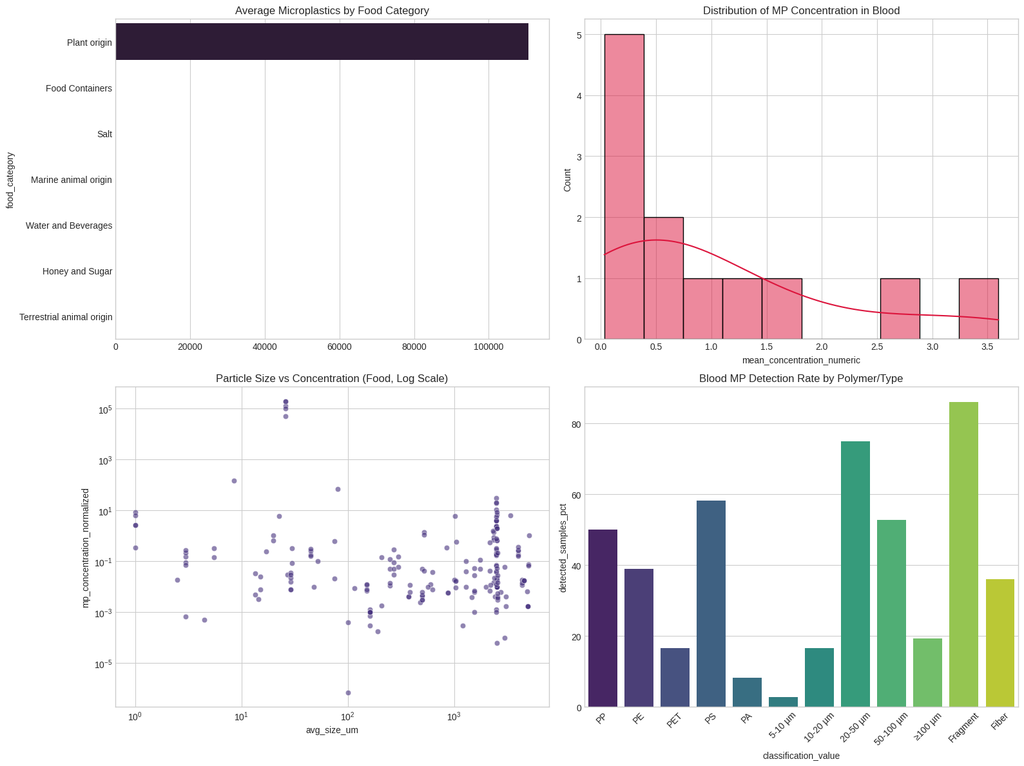

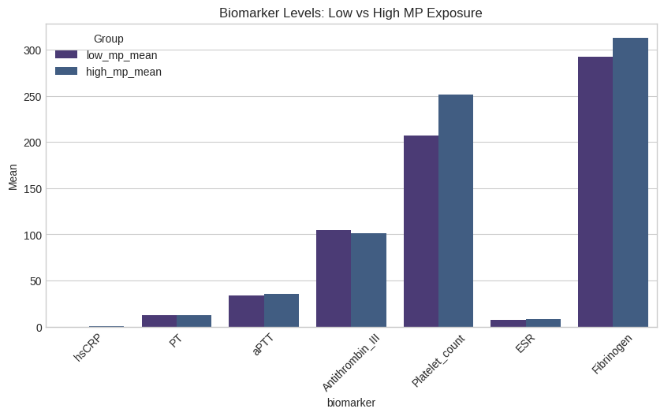

```python
plt.figure(figsize=(16, 12))

# 1. Food Category
plt.subplot(2, 2, 1)
cat_mean = df_food.groupby('food_category')['mp_concentration_normalized'].mean().sort_values(ascending=False).head(8)
sns.barplot(x=cat_mean.values, y=cat_mean.index, palette='rocket')
plt.title('Average Microplastics by Food Category')

# 2. Blood Concentration Distribution
plt.subplot(2, 2, 2)
if not df_blood['mean_concentration_numeric'].isnull().all():
    sns.histplot(df_blood['mean_concentration_numeric'].dropna(), bins=10, kde=True, color='crimson')
    plt.title('Distribution of MP Concentration in Blood')

# 3. Particle Size vs Concentration (Food)
# Extracting average size
def extract_size(text):
    if pd.isna(text): return np.nan
    nums = re.findall(r'\d+', str(text))
    if len(nums) >= 2: return (float(nums[0]) + float(nums[1])) / 2
    if nums: return float(nums[0])
    return np.nan

df_food['avg_size_um'] = df_food['size_range_um'].apply(extract_size)
plt.subplot(2, 2, 3)
sns.scatterplot(data=df_food, x='avg_size_um', y='mp_concentration_normalized', alpha=0.6)
plt.xscale('log')
plt.yscale('log')
plt.title('Particle Size vs Concentration (Food, Log Scale)')

# 4. Blood Detection Rate
plt.subplot(2, 2, 4)
sns.barplot(data=df_blood, x='classification_value', y='detected_samples_pct', palette='viridis')
plt.title('Blood MP Detection Rate by Polymer/Type')
plt.xticks(rotation=45)

plt.tight_layout()
plt.show()

# 4.4 Human Impact (Biomarkers)
plt.figure(figsize=(10, 5))
df_biomarkers['low_mp_mean'] = pd.to_numeric(df_biomarkers['low_mp_mean'], errors='coerce').fillna(df_biomarkers['overall_mean'])
df_biomarkers['high_mp_mean'] = pd.to_numeric(df_biomarkers['high_mp_mean'], errors='coerce').fillna(df_biomarkers['overall_mean'])
df_bio_melt = pd.melt(df_biomarkers, id_vars=['biomarker'], value_vars=['low_mp_mean', 'high_mp_mean'], var_name='Group', value_name='Mean')
sns.barplot(data=df_bio_melt, x='biomarker', y='Mean', hue='Group')
plt.title('Biomarker Levels: Low vs High MP Exposure')
plt.xticks(rotation=45)
plt.show()
```

### 🔹 Step 5: Statistical Analysis

Correlation, Regression, and Hypothesis Testing

```
=== Hypothesis Testing (Biomarkers) ===
hsCRP                | p-val: 0.0084 (Significant)
PT                   | p-val: 0.6627
aPTT                 | p-val: 0.0079 (Significant)
Antithrombin_III     | p-val: 0.1520
Platelet_count       | p-val: 0.0001 (Significant)
ESR                  | p-val: 0.6519
Fibrinogen           | p-val: 0.2470

=== Correlation: Food vs Blood (by Polymer) ===
Pearson Correlation (Food vs Blood): -0.915 (p-value: 0.0850)
```

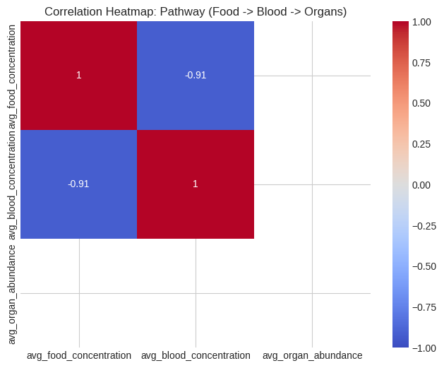

```
Linear Regression R-squared (Predicting Blood from Food): 0.837
```

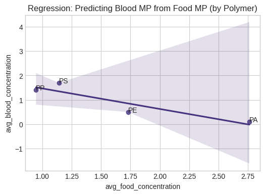

```python
# Hypothesis Testing: Biomarkers (High vs Low MP)
print("=== Hypothesis Testing (Biomarkers) ===")
for i, row in df_biomarkers.iterrows():
    m1, m2 = row['low_mp_mean'], row['high_mp_mean']
    # If standard deviations aren't provided cleanly, estimate for approximation
    s1 = float(row['low_mp_sd']) if pd.notna(row['low_mp_sd']) and str(row['low_mp_sd']).replace('.', '', 1).isdigit() else m1 * 0.2
    s2 = float(row['high_mp_sd']) if pd.notna(row['high_mp_sd']) and str(row['high_mp_sd']).replace('.', '', 1).isdigit() else m2 * 0.2
    n1 = n2 = 30 # standard assumption if N not provided

    if pd.isna(m1) or pd.isna(m2): continue
    t_stat, p_val = stats.ttest_ind_from_stats(m1, s1, n1, m2, s2, n2)
    sig = "(Significant)" if p_val < 0.05 else ""
    print(f"{row['biomarker']:<20} | p-val: {p_val:.4f} {sig}")

# Correlation between Food Contamination and Blood Concentration
print("\n=== Correlation: Food vs Blood (by Polymer) ===")
if len(df_merged_pathway) > 2:
    corr, p = stats.pearsonr(df_merged_pathway['avg_food_concentration'], df_merged_pathway['avg_blood_concentration'])
    print(f"Pearson Correlation (Food vs Blood): {corr:.3f} (p-value: {p:.4f})")

    # Heatmap (Food vs Blood vs Organs)
    plt.figure(figsize=(8, 6))
    corr_matrix = df_merged_pathway[['avg_food_concentration', 'avg_blood_concentration', 'avg_organ_abundance']].corr()
    sns.heatmap(corr_matrix, annot=True, cmap='coolwarm', vmin=-1, vmax=1)
    plt.title('Correlation Heatmap: Pathway (Food -> Blood -> Organs)')
    plt.show()
else:
    print("Not enough overlapping polymer data to perform robust Pearson correlation.")

# Regression: Predict Blood Level from Food Level (using merged polymer data)
from sklearn.linear_model import LinearRegression
if len(df_merged_pathway) > 2:
    X_reg = df_merged_pathway[['avg_food_concentration']]
    y_reg = df_merged_pathway['avg_blood_concentration']
    reg = LinearRegression().fit(X_reg, y_reg)
    print(f"\nLinear Regression R-squared (Predicting Blood from Food): {reg.score(X_reg, y_reg):.3f}")

    plt.figure(figsize=(6, 4))
    sns.regplot(data=df_merged_pathway, x='avg_food_concentration', y='avg_blood_concentration')
    for i, txt in enumerate(df_merged_pathway['polymers']):
        plt.annotate(txt, (df_merged_pathway['avg_food_concentration'].iloc[i], df_merged_pathway['avg_blood_concentration'].iloc[i]))
    plt.title('Regression: Predicting Blood MP from Food MP (by Polymer)')
    plt.show()
```